# AEDD: Trabajo Estadística Espacial

Grupo 4

Curso 2022/2023

```r
library(sf)
```

```r
library(ggplot2)
library(mapSpain)
library(gstat)
load("temp_gal_4.RData")
```

# Ejercicios

### 1. Lectura de datos y análisis exploratorio

1. Realizar un breve análisis descriptivo del conjunto de datos y generar un histograma de la respuesta (comentar).
2. Convertir el `data.frame` a un objeto `sf` (definir el CRS mediante la cadena de texto `"+proj=utm +zone=29T +ellps=WGS84 +units=km"`) y representar la distribución espacial de la respuesta. ¿Se observa algún patrón (más o menos claro)?

```r
( temp.sf<- st_as_sf(temp_gal, coords =c("lon","lat"), remove=FALSE,
                    crs="+proj=utm +zone=29T +ellps=WGS84 +units=km",agr="constant") )
```

```
## Simple feature collection with 154 features and 3 fields
## Attribute-geometry relationship: 3 constant, 0 aggregate, 0 identity
## Geometry type: POINT
## Dimension:     XY
## Bounding box:  xmin: 485.495 ymin: 4639.585 xmax: 684.093 ymax: 4842.957
## CRS:           +proj=utm +zone=29T +ellps=WGS84 +units=km
## First 10 features:
##        lon      lat  temp                 geometry
## 1  559.899 4787.883 20.28 POINT (559.899 4787.883)
## 2  589.613 4799.508 17.90 POINT (589.613 4799.508)
## 3  654.874 4822.648 19.57 POINT (654.874 4822.648)
## 4  636.839 4664.377 20.40 POINT (636.839 4664.377)
## 5  497.652 4711.419 19.81 POINT (497.652 4711.419)
## 6  560.458 4815.665 20.41 POINT (560.458 4815.665)
## 7  518.308 4732.587 18.23 POINT (518.308 4732.587)
## 8  618.455 4761.028 20.36 POINT (618.455 4761.028)
## 9  598.825 4786.697 17.70 POINT (598.825 4786.697)
## 10 623.157 4703.404 19.93 POINT (623.157 4703.404)
```

```r
z <- temp.sf$temp
str(temp_gal)
```

```
## 'data.frame':    154 obs. of  3 variables:
##  $ lon : num  560 590 655 637 498 ...
##  $ lat : num  4788 4800 4823 4664 4711 ...
##  $ temp: num  20.3 17.9 19.6 20.4 19.8 ...
##  - attr(*, "fecha")= chr "8/2022"
```

```r
summary(temp_gal)
```

```
##       lon             lat            temp
##  Min.   :485.5   Min.   :4640   Min.   :16.15
##  1st Qu.:529.8   1st Qu.:4685   1st Qu.:18.82
##  Median :576.6   Median :4710   Median :20.17
##  Mean   :580.0   Mean   :4725   Mean   :20.18
##  3rd Qu.:625.5   3rd Qu.:4768   3rd Qu.:21.23
##  Max.   :684.1   Max.   :4843   Max.   :24.95
```

```r
summary(z)
```

```
##    Min. 1st Qu.  Median    Mean 3rd Qu.    Max.
##   16.15   18.82   20.17   20.18   21.23   24.95
```

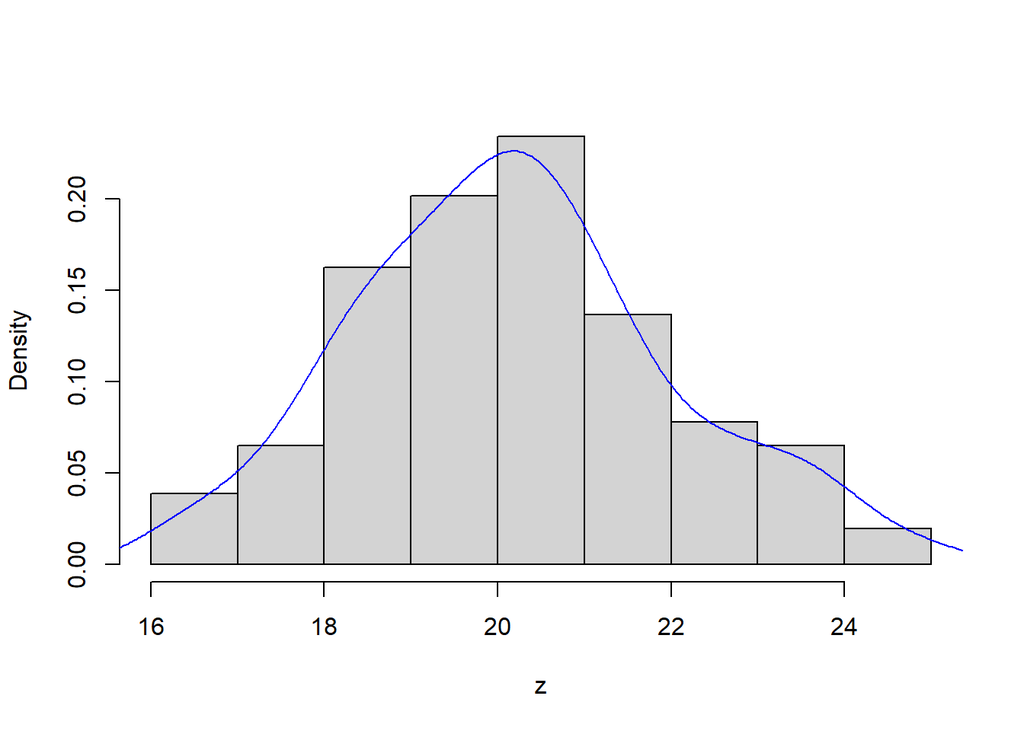

```r
hist(z, main="", freq=FALSE)
lines(density(z),col="blue")
```

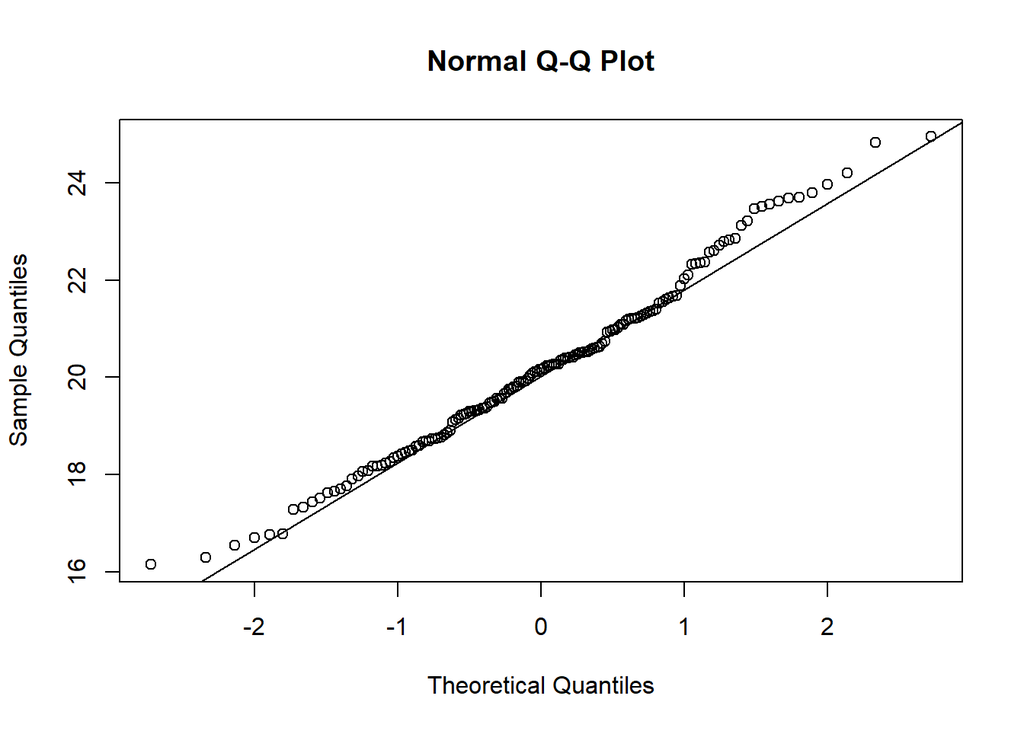

```r
qqnorm(z)
qqline(z)
```

```r
shapiro.test(z)
```

```
##
##  Shapiro-Wilk normality test
##
## data:  z
## W = 0.98793, p-value = 0.2054
```

Podemos observar la presencia de cierta normalidad en los datos.

A continuación mostraremos la distribución espacial de los datos, asignando un color dependiendo de la temperatura medida en cada observación.

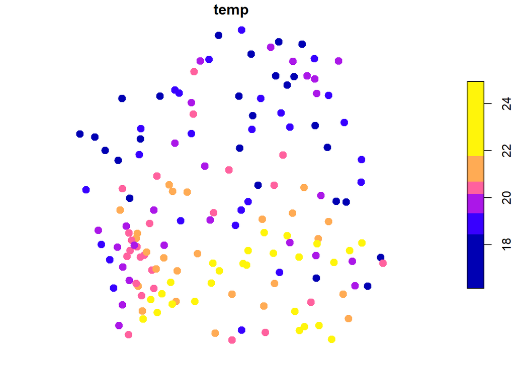

```r
plot(temp.sf["temp"], pch=20, cex=2, breaks="quantile", nbreaks=6)
```

Podemos ver que las temperaturas más altas tienden a agruparse entorno a las zonas más bajas, especialmente en la esquina inferior izquierda. Zonas correspondientes a las provincias de Ourense y Pontevedra.

.

3. Completar el análisis descriptivo de la variabilidad de gran escala. ¿Aparentemente hay tendencia espacial? En caso afirmativo, sugerir un modelo lineal.

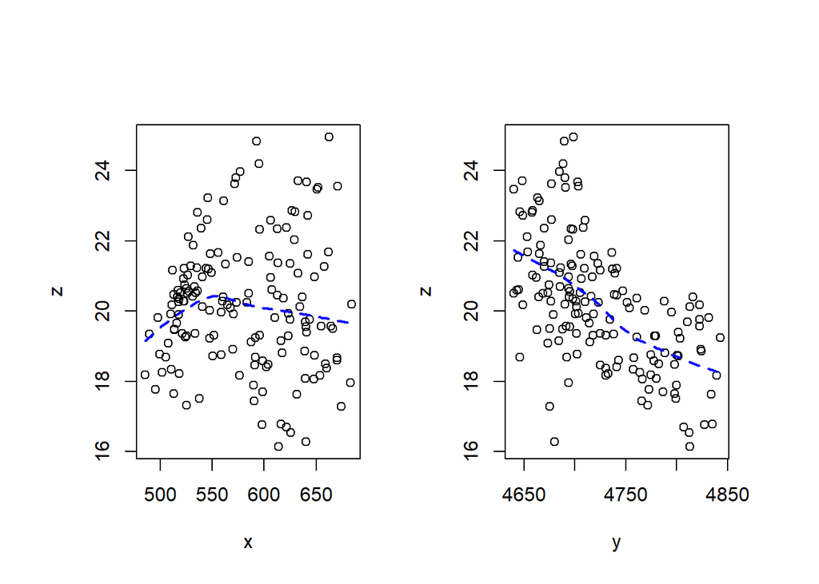

```r
coord <- st_coordinates(temp.sf)
old.par <- par(mfrow = c(1, 2), omd = c(0.05, 0.95, 0.01, 0.95))
plot(coord[, 1], z, xlab = "x", ylab = "z")
lines(lowess(coord[, 1], z), lty = 2, lwd = 2, col = 'blue')
plot(coord[, 2], z, xlab = "y", ylab = "z")
lines(lowess(coord[, 2], z), lty = 2, lwd = 2, col = 'blue')
```

```r
par(old.par)
```

Podremos observar que la longitud no tiene mucha influencia en la temperatura, mientras que si podemos apreciar cierta tendencia negativa en la latitud.

```r
ajuste<-lm(temp ~lat, data = temp.sf)
summary(ajuste)
```

```
##
## Call:
## lm(formula = temp ~ lat, data = temp.sf)
##
## Residuals:
##     Min      1Q  Median      3Q     Max
## -4.7683 -1.1307 -0.1308  1.0798  4.2508
##
## Coefficients:
##               Estimate Std. Error t value Pr(>|t|)
## (Intercept) 113.103598  10.352806  10.925  < 2e-16 ***
## lat          -0.019668   0.002191  -8.976 9.92e-16 ***
## ---
## Signif. codes:  0 '***' 0.001 '**' 0.01 '*' 0.05 '.' 0.1 ' ' 1
##
## Residual standard error: 1.481 on 152 degrees of freedom
## Multiple R-squared:  0.3465, Adjusted R-squared:  0.3422
## F-statistic: 80.58 on 1 and 152 DF,  p-value: 9.918e-16
```

```r
re<- residuals(ajuste)
summary(re)
```

```
##    Min. 1st Qu.  Median    Mean 3rd Qu.    Max.
## -4.7683 -1.1307 -0.1308  0.0000  1.0798  4.2508
```

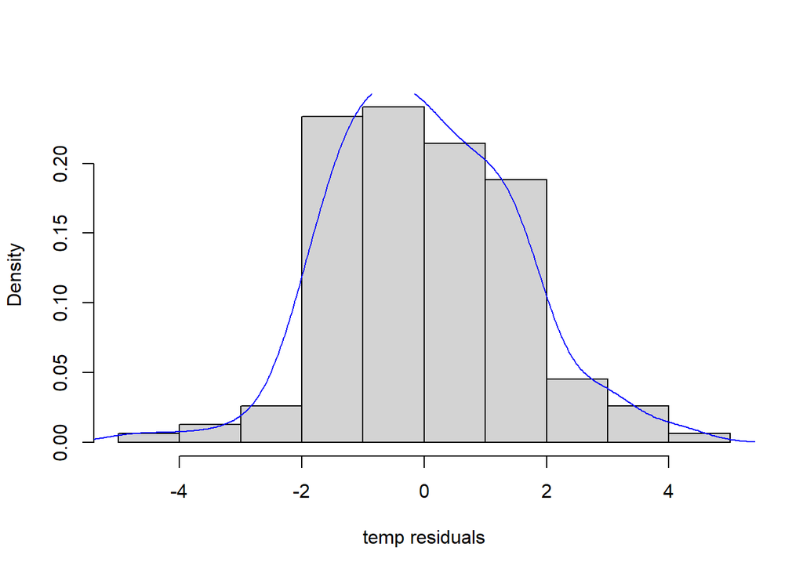

```r
hist(re, xlab = "temp residuals", main = "", freq = FALSE)
lines(density(re), col = 'blue')
```

Se puede apreciar cierta simetría en los residuos del ajuste.

.

4. Volver a representar la distribución espacial de la respuesta (o solo las posiciones de observación si surgen dificultades) junto con los lÃmites administrativos de Galicia (que se pueden obtener empleando el paquete `mapSpain`).

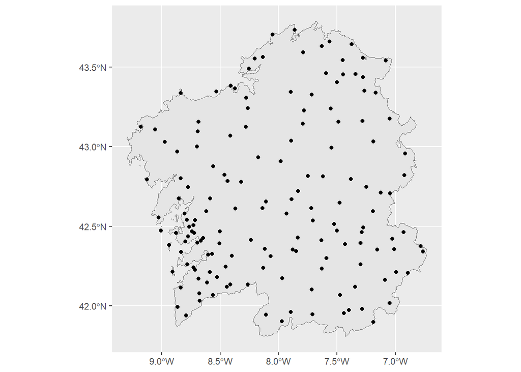

```r
galicia.sf<-esp_get_ccaa(ccaa="Galicia")
ggplot()+geom_sf(data=galicia.sf) + geom_sf(data=temp.sf)
```

### 2. Modelado de la dependencia espacial

1. Analiza la variabilidad de pequeña escala empleando el estimador robusto del semivariograma (considerando 25 saltos hasta un salto máximo de 160).

```r
maxlag <- 160
vario <- variogram(temp~lat, temp.sf, cutoff = maxlag, width = maxlag/25, cressie=TRUE)
vario$dist
```

```
##  [1]   4.333762  10.101194  16.318187  22.504678  28.751448  35.201724
##  [7]  41.499109  47.969947  54.345376  60.771292  67.254037  73.701140
## [13]  79.874901  86.309723  92.689815  99.193313 105.445230 112.091206
## [19] 118.368008 124.733855 131.146617 137.575691 143.888791 150.506166
## [25] 156.769519
```

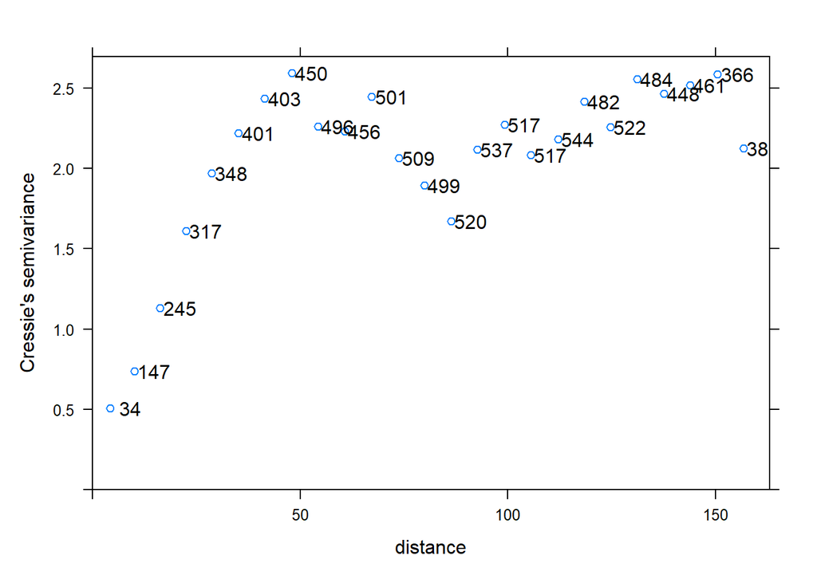

```r
plot(vario, plot.numbers = TRUE)
```

2. Ajustar a las estimaciones robustas un modelo de semivariograma (isotrópico) exponencial y uno esférico, mediante WLS. ¿Con cuál se obtiene un mejor ajuste? Interpretar las estimaciones obtenidas de los parámetros del semivariograma.

.

Comenzamos creando el modelo exponencial

```r
modelo_exp <- vgm(model = "Exp", nugget = NA)
(fit_exp <- fit.variogram(vario, modelo_exp, fit.method = 2))
```

```
##   model    psill    range
## 1   Nug 0.000000  0.00000
## 2   Exp 2.342549 19.79145
```

```r
nugget_exp <- fit_exp$psill[1]
sill_exp <- nugget_exp + fit_exp$psill[2]
range_exp <- 3*fit_exp$range[2]
c(nugget_exp, sill_exp, range_exp)
```

```
## [1]  0.000000  2.342549 59.374345
```

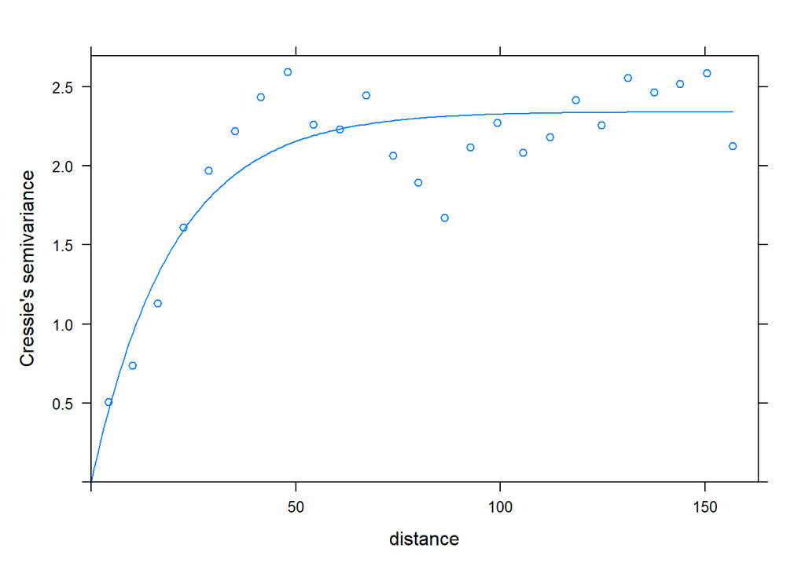

```r
plot(vario, fit_exp)
```

El variograma exponencial tendrá el nugget en el origen, lo que indica una fuerte dependencia de los datos. El valor del range nos indica el punto en el que converge nuestro modelo de semivariograma, es decir, a partir de que punto se vuelve constante para el eje Y. En este caso, tiene un valor de 59.37 que representa la distancia a partir de la cuál las muestras tomadas comienzan a ser independientes. Por ultimo, veremos que el umbral será la altura en el eje y en la que converge el modelo sera 2.34.

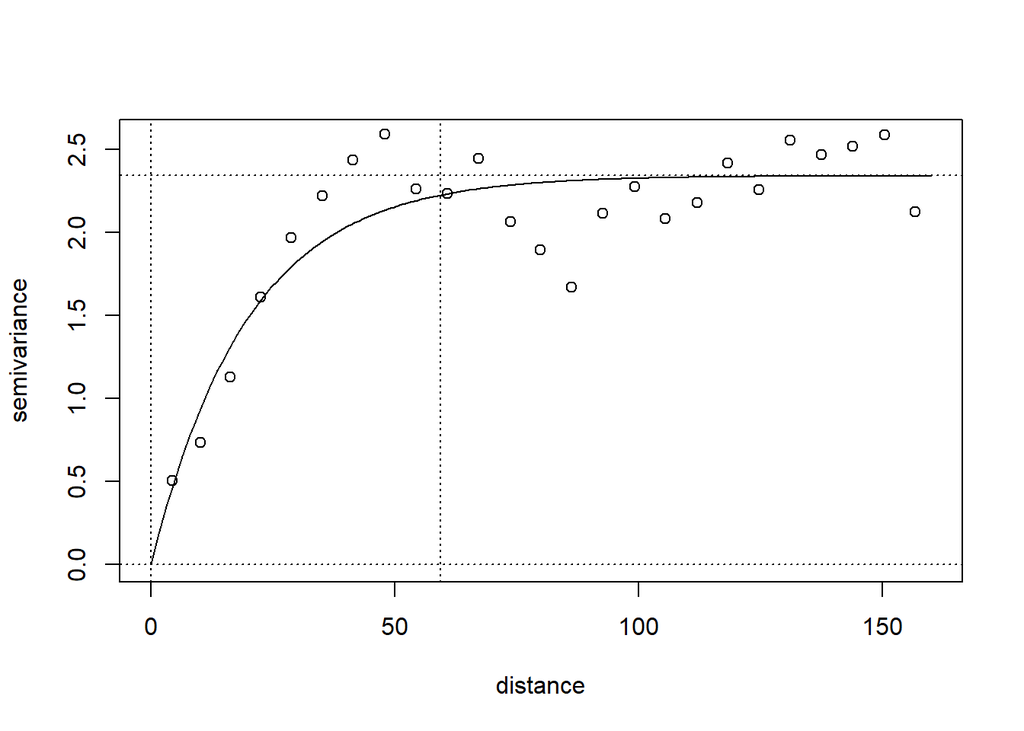

```r
plot(vario$dist, vario$gamma, xlab = "distance", ylab = "semivariance",
     xlim = c(0, max(range_exp*1.1, maxlag)), ylim = c(0, sill_exp*1.1))
lines(variogramLine(fit_exp, maxdist = max(range_exp*1.1, maxlag)))
abline(v = 0, lty = 3)
abline(v = range_exp, lty = 3)
abline(h = nugget_exp, lty = 3)
abline(h = sill_exp, lty = 3)
```

Creamos el modelo esférico

```r
modelo_sph <- vgm(model = "Sph", nugget = NA)
( fit_sph <- fit.variogram(vario, modelo_sph, fit.method = 2)  )
```

```
##   model    psill    range
## 1   Nug 0.000000  0.00000
## 2   Sph 2.263629 42.95586
```

```r
nugget_sph <- fit_sph$psill[1]
sill_sph <- nugget_sph + fit_sph$psill[2]
range_sph <- fit_sph$range[2]
c(nugget_sph, sill_sph, range_sph)
```

```
## [1]  0.000000  2.263629 42.955858
```

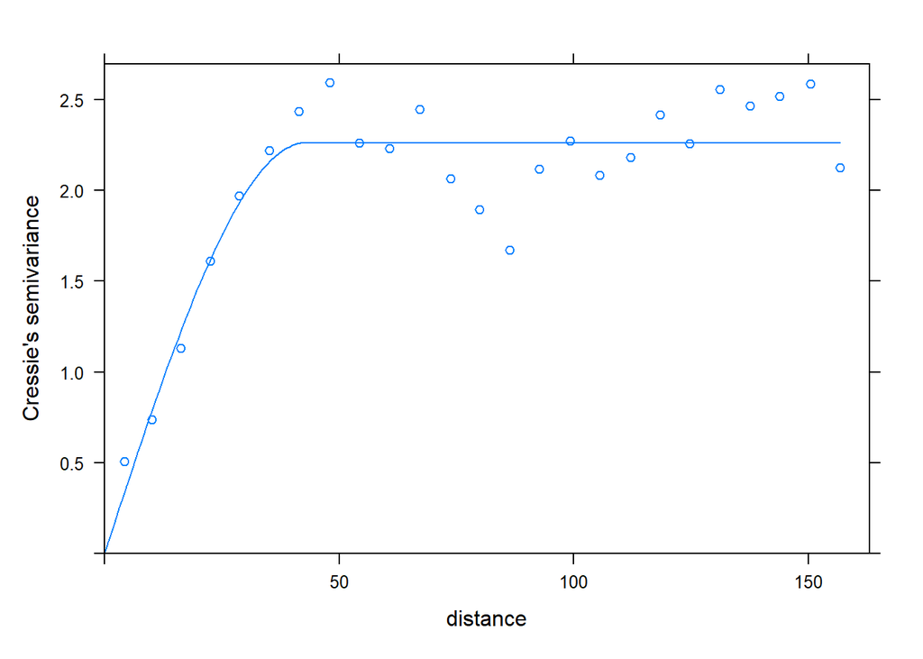

```r
plot(vario, fit_sph)
```

El variograma esférico al igual que el exponencial tendrá el nugget en el origen, lo que vuelve a reflejar la fuerte dependencia de los datos. El valor del range nos indica el punto en el que converge nuestro modelo de semivariograma, es decir, a partir de que punto se vuelve constante para el eje Y. En este caso, tiene un valor de 42.96 que representa la distancia a partir de la cuál las muestras tomadas comienzan a ser independientes. Por ultimo, veremos que el umbral será la altura en el eje y en la que converge el modelo sera 2.26.

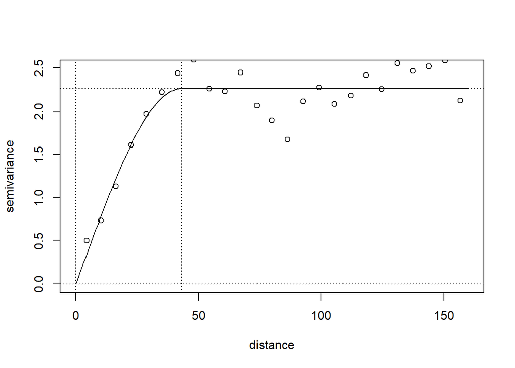

```r
plot(vario$dist, vario$gamma, xlab = "distance", ylab = "semivariance",
     xlim = c(0, max(range_sph*1.1, maxlag)), ylim = c(0, sill_sph*1.1))
lines(variogramLine(fit_sph, maxdist = max(range_sph*1.1, maxlag)))
abline(v = 0, lty = 3)
abline(v = range_sph, lty = 3)
abline(h = nugget_sph, lty = 3)
abline(h = sill_sph, lty = 3)
```

Compararemos los errores cuadráticos de los dos modelos

```r
# error exponencial
attr(fit_exp, "SSErr")
```

```
## [1] 194.135
```

```r
# error esferico
attr(fit_sph, "SSErr")
```

```
## [1] 118.2087
```

El modelo esférico generara un menor error de ajuste, aun así realizaremos la comparación empleando validación cruzada

.

3. Emplear medidas de validación cruzada, considerando 10 grupos, para seleccionar el modelo final (establecer la semilla igual al número de grupo multiplicado por 10; no es necesario generar gráficos).

```r
set.seed(4*10)
cv_exp <- krige.cv(formula = temp~lat, locations = temp.sf,
                   model = fit_exp,nfold = 10)

cv_sph <- krige.cv(formula = temp~lat, locations = temp.sf,
                   model = fit_sph,nfold = 10)

summary_cv <- function(cv.data, na.rm = FALSE,
                       tol = sqrt(.Machine$double.eps)) {
  err <- cv.data$residual      # Errores
  obs <- cv.data$observed
  z <- cv.data$zscore
  w <- 1/pmax(cv.data$var1.var, tol) # Ponderación según varianza kriging
  if(na.rm) {
    is.a <- !is.na(err)
    err <- err[is.a]
    obs <- obs[is.a]
    z <- z[is.a]
    w <- w[is.a]
  }
  perr <- 100*err/pmax(obs, tol)  # Errores porcentuales
  return(c(
    # Medidas de error tradicionales
    me = mean(err),           # Error medio
    rmse = sqrt(mean(err^2)), # Raíz del error cuadrático medio
    mae = mean(abs(err)),     # Error absoluto medio
    mpe = mean(perr),         # Error porcentual medio
    mape = mean(abs(perr)),   # Error porcentual absoluto medio
    r.squared = 1 - sum(err^2)/sum((obs - mean(obs))^2), # Pseudo R-cuadrado
    # Medidas de error que tienen en cuenta la varianza kriging
    dme = mean(z),            # Error estandarizado medio
    dmse = sqrt(mean(z^2)),    # Error cuadrático medio adimensional
    rwmse = sqrt(weighted.mean(err^2, w)) # Raíz del ECM ponderado
  ))
}

summary_cv(cv_exp)
```

```
##          me        rmse         mae         mpe        mape   r.squared
## -0.02684147  1.23502058  0.90751293 -0.47484935  4.56630081  0.53955275
##         dme        dmse       rwmse
## -0.01408447  1.19711355  1.15715198
```

```r
summary_cv(cv_sph)
```

```
##          me        rmse         mae         mpe        mape   r.squared
## -0.03036628  1.23106029  0.92895328 -0.44436973  4.67746812  0.54250101
##         dme        dmse       rwmse
## -0.01355704  1.45964741  1.18641787
```

Pese a no haber diferencias muy notorias, el modelo exponencial será algo mejor que el esférico.

.

### 3. Predicción espacial

1. Crear una rejilla de predicción de dimensiones 100x100 que cubra los límites de Galicia e intersecarla con dicha región (o una rejilla que cubra las posiciones de observación si surgen dificultades).

```r
galicia.sf<-esp_get_ccaa(ccaa ="Galicia")

library(stars)
buffer <- temp.sf %>% st_geometry() %>% st_buffer(10)

grid<- buffer %>% st_as_stars(nx=100,ny=100)

coord <- st_coordinates(grid)
grid$lon <- coord$x
grid$lat <- coord$y

grid <- grid %>% st_crop(buffer)
```

2. Empleando el modelo obtenido en el ejercicio anterior, obtener la correspondiente superficie de predicción y varianza kriging (en la rejilla de predicción).

```r
pred<- krige(formula= temp~ lat , locations=temp.sf, model=fit_exp, newdata=grid)
```

```
## [using universal kriging]
```

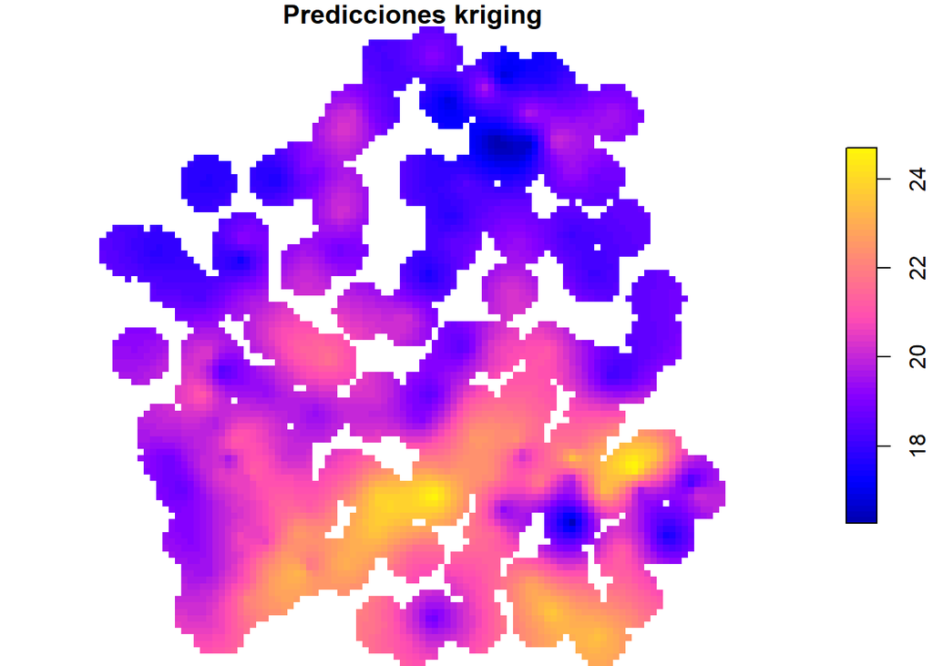

```r
grid$var1.pred <- pred$var1.pred
grid$var1.var <- pred$var1.var

plot(grid["var1.pred"], breaks = "equal", col = sf.colors(64), key.pos = 4,
     main = "Predicciones kriging")
```

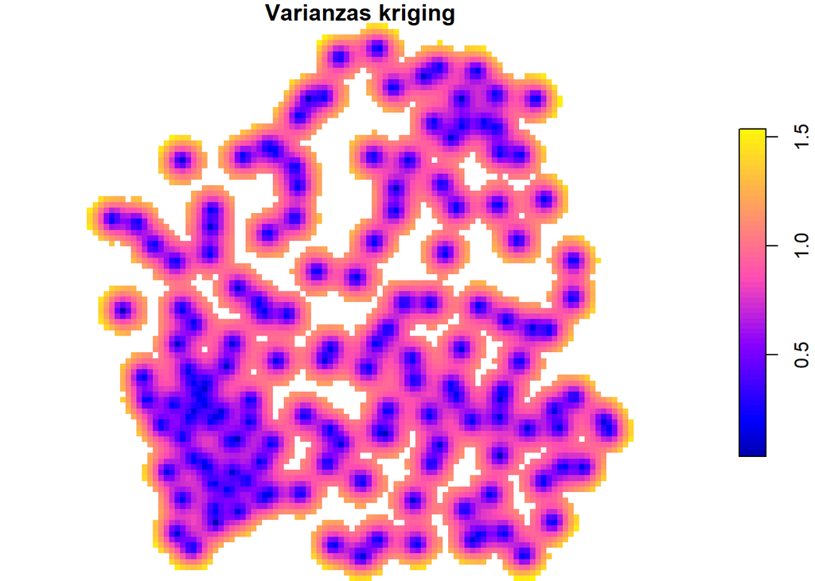

```r
plot(grid["var1.var"], breaks = "equal", col = sf.colors(64), key.pos = 4,
     main = "Varianzas kriging")
```